# Chapter 3 Project

Bianca Amoako

2024-03-09

```r
library(tidyverse)
library(openintro)
```

```r
data(kobe_basket)
glimpse(kobe_basket)
```

```
## Rows: 133
## Columns: 6
## $ vs          <fct> ORL, ORL, ORL, ORL, ORL, ORL, ORL, ORL, ORL, ORL, ORL, ORL…
## $ game        <int> 1, 1, 1, 1, 1, 1, 1, 1, 1, 1, 1, 1, 1, 1, 1, 1, 1, 1, 1, 1…
## $ quarter     <fct> 1, 1, 1, 1, 1, 1, 1, 1, 1, 2, 2, 2, 2, 2, 2, 2, 2, 2, 3, 3…
## $ time        <fct> 9:47, 9:07, 8:11, 7:41, 7:03, 6:01, 4:07, 0:52, 0:00, 6:35…
## $ description <fct> Kobe Bryant makes 4-foot two point shot, Kobe Bryant misse…
## $ shot        <chr> "H", "M", "M", "H", "H", "M", "M", "M", "M", "H", "H", "H"…
```

### Exercise 1

A streak length of 1 means that Kobe Bryant made only 1 hit before missing 1 shot. A streak of 1 would look like: H M | A streak length of 0 means that Kobe Bryant missed two times in a row. A streak of 0 would look like: | M |

### Exercise 2

The distribution of Kobe’s streak lengths show that his typical streak length is 0 because he missed two times in a row the most, and his longest streak was 4 hits.

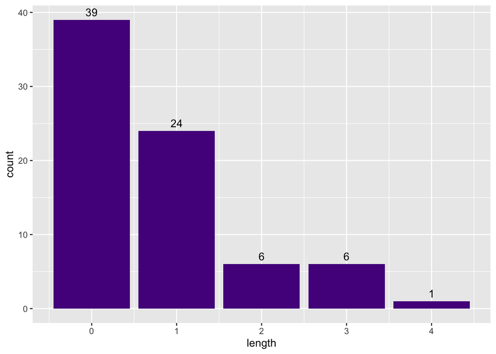

```r
#kobe_basket$shot
kobe_streak <- calc_streak(kobe_basket$shot)
ggplot(data = kobe_streak, aes(x = length)) + geom_bar(fill = "purple4") + geom_text(stat = "count", aes(label = after_stat(count)), vjust = -0.5)
```

```r
#length = the length of the streak
```

### Exercise 3

In the simulation of the unfair coin, heads came up 24 times. Using the set seed, the data frame number_unfair_head contains the outcomes of the seed piped into a filter looking for heads, then makes a new row with the number of heads, and finally prints the count. Nrow() and print() don’t have inputs because the information needed preceeds their invocation through piping.

```r
set.seed(123456) #setting the seed for simulation
coin_outcomes <- c("heads", "tails")
sim_unfair_coin <- sample(coin_outcomes, size = 100, replace = 100, prob = c(0.2, 0.8))
#coin_outcomes = vector
#c() = the possible outcomes
#sample(vector, # rounds, T = independent F = dependent) = simulation run, prob = c(weighted prob, weighted prob)
sim_unfair_coin #call the simulation
```

```
##   [1] "tails" "tails" "tails" "tails" "tails" "tails" "tails" "tails" "heads"
##  [10] "tails" "tails" "tails" "heads" "heads" "heads" "heads" "heads" "tails"
##  [19] "tails" "tails" "tails" "tails" "tails" "tails" "tails" "tails" "heads"
##  [28] "heads" "heads" "tails" "tails" "heads" "tails" "tails" "heads" "tails"
##  [37] "heads" "heads" "tails" "tails" "tails" "tails" "heads" "tails" "tails"
##  [46] "tails" "tails" "tails" "tails" "tails" "tails" "tails" "tails" "heads"
##  [55] "tails" "heads" "heads" "heads" "tails" "tails" "tails" "tails" "tails"
##  [64] "tails" "tails" "tails" "tails" "tails" "tails" "tails" "tails" "tails"
##  [73] "heads" "tails" "heads" "tails" "heads" "tails" "tails" "tails" "tails"
##  [82] "tails" "heads" "heads" "tails" "tails" "tails" "tails" "tails" "tails"
##  [91] "tails" "tails" "tails" "tails" "tails" "tails" "heads" "tails" "tails"
## [100] "tails"
```

```r
number_unfair_heads <- data.frame(unfair_coin = sim_unfair_coin) %>% filter(unfair_coin=="heads") %>% nrow() %>% print()
```

```
## [1] 24
```

…

### Exercise 4

In order for the simulation to reflect a shooting percentage of 45%, the sample function needs the argument prob = c(45, 55)

```r
set.seed(2468)
shot_outcomes <- c("H", "M")
sim_basket <- sample(shot_outcomes, size = 133, replace = TRUE, prob = c(45, 55))
sim_basket
```

```
##   [1] "M" "H" "M" "H" "M" "M" "H" "M" "H" "M" "M" "M" "M" "H" "M" "H" "M" "M"
##  [19] "M" "H" "M" "H" "M" "M" "M" "H" "H" "H" "M" "H" "M" "H" "M" "H" "M" "M"
##  [37] "H" "M" "M" "H" "M" "M" "H" "M" "H" "M" "H" "M" "M" "M" "H" "H" "H" "H"
##  [55] "M" "M" "H" "M" "M" "H" "M" "M" "M" "M" "H" "H" "M" "M" "H" "M" "M" "M"
##  [73] "H" "M" "M" "M" "H" "M" "M" "M" "M" "H" "M" "M" "M" "H" "M" "M" "M" "H"
##  [91] "H" "M" "H" "H" "H" "M" "H" "M" "M" "M" "M" "H" "H" "M" "H" "M" "M" "M"
## [109] "H" "M" "M" "H" "H" "H" "H" "H" "M" "M" "M" "M" "M" "M" "M" "M" "H" "H"
## [127] "M" "H" "M" "M" "M" "H" "M"
```

```r
table(sim_basket)
```

```
## sim_basket
##  H  M
## 51 82
```

### Exercise 5

```r
sim_streak <- calc_streak(sim_basket)
```

### Exercise 6

The typical streak length for the simulated independent shooter with a 45% shooting rate is 0. The longest streak in 133 shots is 5.

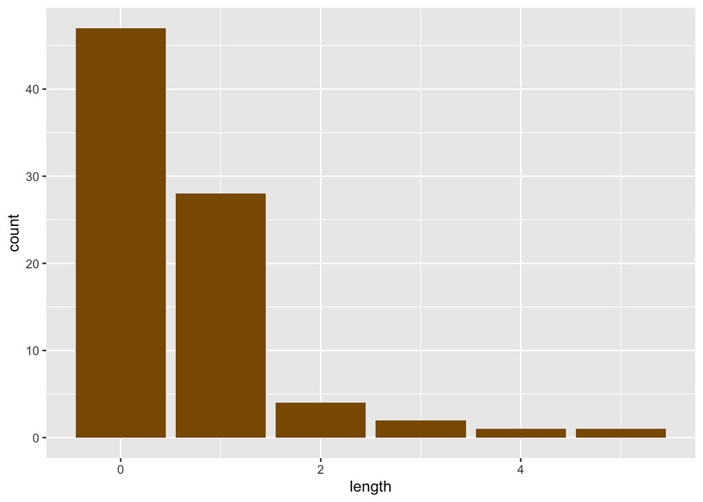

```r
ggplot(data = sim_streak, aes(x = length)) + geom_bar(fill = "orange4")
```

```r
mean(sim_streak$length)
```

```
## [1] 0.6144578
```

### Exercise 7

If I were to run the independent shooter from above a second time, the distribution would be similar because the outcome can’t escape the 45% probability. There distribution would be skewed right.

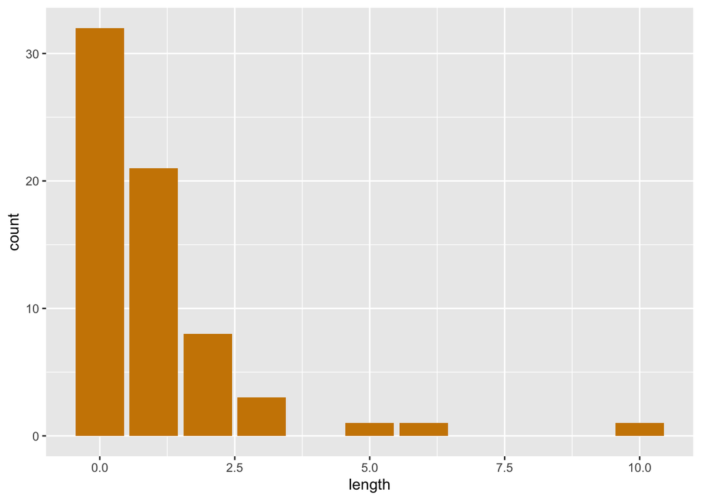

```r
shot_outcomes <- c("H", "M")
sim_basket <- sample(shot_outcomes, size = 133, replace = TRUE, prob = c(45, 55))
sim_streak2 <- calc_streak(sim_basket)
ggplot(data = sim_streak2, aes(x = length)) + geom_bar(fill = "orange3")
```

```r
mean(sim_streak2$length)
```

```
## [1] 1
```

### Exercise 8

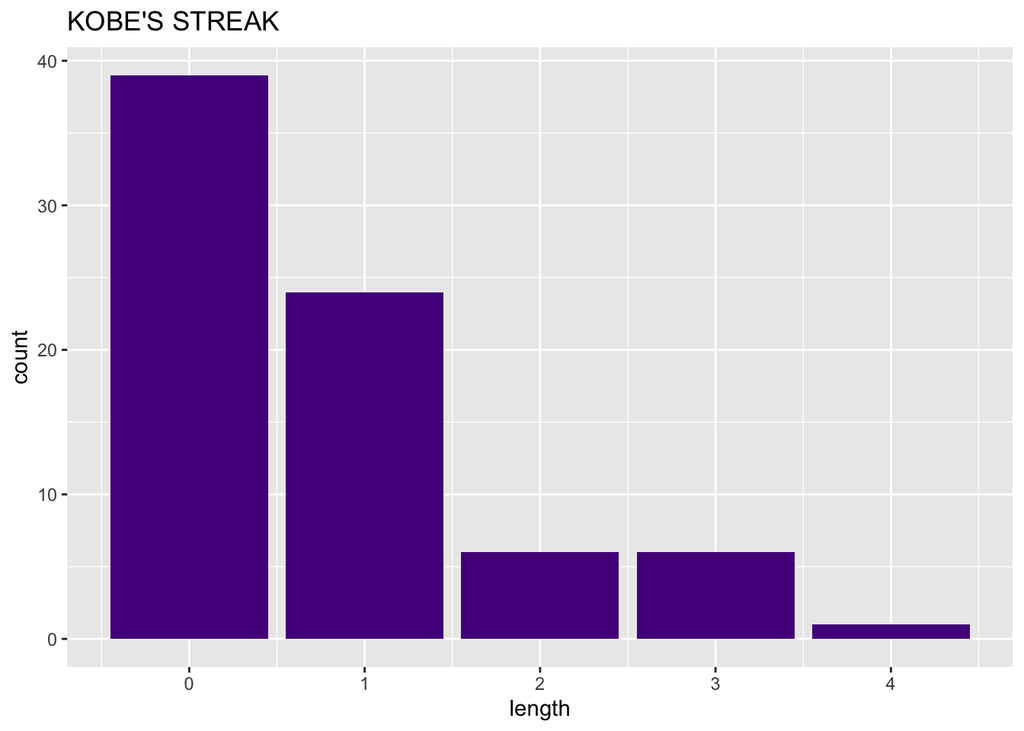

```r
ggplot(data = kobe_streak, aes(x = length)) + geom_bar(fill = "purple4") + ggtitle("KOBE'S STREAK")
```

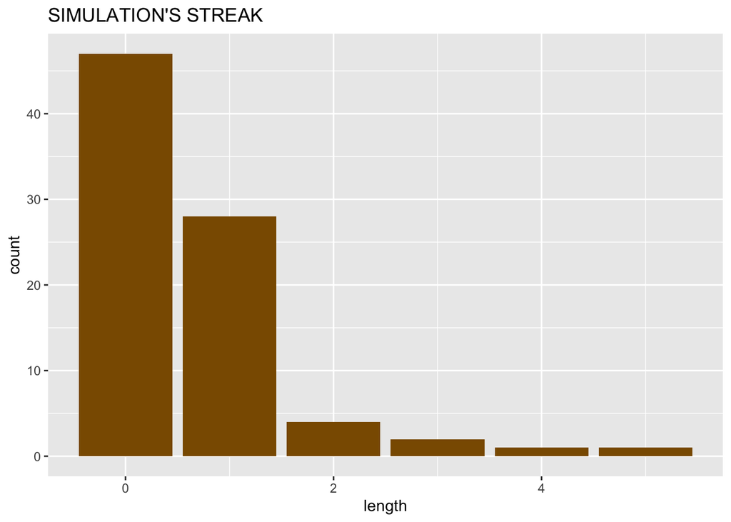

```r
ggplot(data = sim_streak, aes(x = length)) + geom_bar(fill = "orange4") + ggtitle("SIMULATION'S STREAK")
```

```r
kobe_streak %>% summarise(kobe_streak_mean = mean(length))
```

```
##   kobe_streak_mean
## 1        0.7631579
```

```r
sim_streak %>% summarise(sim_streak_mean = mean(length))
```

```
##   sim_streak_mean
## 1       0.6144578
```